# Eda_notebook

## Introduction

The aim of this project is to use Explanatory Data Analysis (EDA) to recommend a house for Mr Thomas hansen and his family(5kids) in a nice neighborhood. This project will covers just simple visualization that will help our stakeholder make a decision of where he wants to stay with limited resources. This notebook is mearnt to apply my understanding in data science projects. It contains:

- Data cleaning
- EDA & data Visualization

Please this project is still subject to further improvements as i am still in the processes of learning. feel free to add your contributions or better approaches you consider might be better

## Hypothesis:

- The prices of houses increases with the grade of the neighborhood.

## Question:

These notebook seeks to answer the following question:

- What are they available neighborhood for Mr Thomas
- Does location impact the price of a home
- which Neigborhood can we recommend to Thomas and his family based on his budget.

## Stakeholder Requirements:

- Mr. Thomas has 5kids,and require a 6 bedrooms house.
- Mr.Thomas is on a budget,his budget is betweeen $200000.00-400000.00
- He want an average or a decent house based on his budget.

## Importing Libaries and Data Set

```python
# Import packages

# Data libraries
import pandas as pd
import numpy as np
import psycopg2

#Visualization of data
import matplotlib.pyplot as plt
%matplotlib inline
import seaborn as sns
import plotly.express as px
import plotly.graph_objects as go
import geojson
```

```python
# Importing Data
df = pd.read_csv('data/King_County_House_prices_dataset.csv')
```

## Understanding the data set.

Column Names and descriptions for King County Data Set

- **id** - unique identified for a house
- **dateDate** - house was sold
- **pricePrice** - is prediction target
- **bedroomsNumber** - # of bedrooms
- **bathroomsNumber** - # of bathrooms
- **sqft_livingsquare** - footage of the home
- **sqft_lotsquare** - footage of the lot
- **floorsTotal** - floors (levels) in house
- **waterfront** - House which has a view to a waterfront
- **view** - Has been viewed
- **condition** - How good the condition is ( Overall )
- **grade** - overall grade given to the housing unit, based on King County grading system
- **sqft_above** - square footage of house apart from basement
- **sqft_basement** - square footage of the basement
- **yr_built** - Built Year
- **yr_renovated** - Year when house was renovated
- **zipcode** - zip
- **lat** - Latitude coordinate
- **long** - Longitude coordinate
- **sqft_living15** - The square footage of interior housing living space for the nearest 15 neighbors
- **sqft_lot15** - The square footage of the land lots of the nearest 15 neighbors

```python
df.head(2)
# Aim: To display the head of the first 5 columns of the dataframe
```

|  | id | date | price | bedrooms | bathrooms | sqft_living | sqft_lot | floors | waterfront | view | ... | grade | sqft_above | sqft_basement | yr_built | yr_renovated | zipcode | lat | long | sqft_living15 | sqft_lot15 |
| --- | --- | --- | --- | --- | --- | --- | --- | --- | --- | --- | --- | --- | --- | --- | --- | --- | --- | --- | --- | --- | --- |
| 0 | 7129300520 | 10/13/2014 | 221900.0 | 3 | 1.00 | 1180 | 5650 | 1.0 | NaN | 0.0 | ... | 7 | 1180 | 0.0 | 1955 | 0.0 | 98178 | 47.5112 | -122.257 | 1340 | 5650 |
| 1 | 6414100192 | 12/9/2014 | 538000.0 | 3 | 2.25 | 2570 | 7242 | 2.0 | 0.0 | 0.0 | ... | 7 | 2170 | 400.0 | 1951 | 1991.0 | 98125 | 47.7210 | -122.319 | 1690 | 7639 |

2 rows × 21 columns

```python
df.view.unique()
```

```
array([ 0., nan,  3.,  4.,  2.,  1.])
```

```python
df.view.nunique()
```

```
5
```

```python
df.dtypes

# Aim: To obtain a statistical summary of the dataframe.
```

```
id                 int64
date              object
price            float64
bedrooms           int64
bathrooms        float64
sqft_living        int64
sqft_lot           int64
floors           float64
waterfront       float64
view             float64
condition          int64
grade              int64
sqft_above         int64
sqft_basement     object
yr_built           int64
yr_renovated     float64
zipcode            int64
lat              float64
long             float64
sqft_living15      int64
sqft_lot15         int64
dtype: object
```

```python
df.info()
```

```
<class 'pandas.core.frame.DataFrame'>
RangeIndex: 21597 entries, 0 to 21596
Data columns (total 21 columns):
 #   Column         Non-Null Count  Dtype
---  ------         --------------  -----
 0   id             21597 non-null  int64
 1   date           21597 non-null  object
 2   price          21597 non-null  float64
 3   bedrooms       21597 non-null  int64
 4   bathrooms      21597 non-null  float64
 5   sqft_living    21597 non-null  int64
 6   sqft_lot       21597 non-null  int64
 7   floors         21597 non-null  float64
 8   waterfront     19221 non-null  float64
 9   view           21534 non-null  float64
 10  condition      21597 non-null  int64
 11  grade          21597 non-null  int64
 12  sqft_above     21597 non-null  int64
 13  sqft_basement  21597 non-null  object
 14  yr_built       21597 non-null  int64
 15  yr_renovated   17755 non-null  float64
 16  zipcode        21597 non-null  int64
 17  lat            21597 non-null  float64
 18  long           21597 non-null  float64
 19  sqft_living15  21597 non-null  int64
 20  sqft_lot15     21597 non-null  int64
dtypes: float64(8), int64(11), object(2)
memory usage: 3.5+ MB
```

```python
df.shape

# Aim: to show the total number s of rows and columns
```

```
(21597, 21)
```

```python
df.describe()
```

|  | id | price | bedrooms | bathrooms | sqft_living | sqft_lot | floors | waterfront | view | condition | grade | sqft_above | yr_built | yr_renovated | zipcode | lat | long | sqft_living15 | sqft_lot15 |
| --- | --- | --- | --- | --- | --- | --- | --- | --- | --- | --- | --- | --- | --- | --- | --- | --- | --- | --- | --- |
| count | 2.159700e+04 | 2.159700e+04 | 21597.000000 | 21597.000000 | 21597.000000 | 2.159700e+04 | 21597.000000 | 19221.000000 | 21534.000000 | 21597.000000 | 21597.000000 | 21597.000000 | 21597.000000 | 17755.000000 | 21597.000000 | 21597.000000 | 21597.000000 | 21597.000000 | 21597.000000 |
| mean | 4.580474e+09 | 5.402966e+05 | 3.373200 | 2.115826 | 2080.321850 | 1.509941e+04 | 1.494096 | 0.007596 | 0.233863 | 3.409825 | 7.657915 | 1788.596842 | 1970.999676 | 83.636778 | 98077.951845 | 47.560093 | -122.213982 | 1986.620318 | 12758.283512 |
| std | 2.876736e+09 | 3.673681e+05 | 0.926299 | 0.768984 | 918.106125 | 4.141264e+04 | 0.539683 | 0.086825 | 0.765686 | 0.650546 | 1.173200 | 827.759761 | 29.375234 | 399.946414 | 53.513072 | 0.138552 | 0.140724 | 685.230472 | 27274.441950 |
| min | 1.000102e+06 | 7.800000e+04 | 1.000000 | 0.500000 | 370.000000 | 5.200000e+02 | 1.000000 | 0.000000 | 0.000000 | 1.000000 | 3.000000 | 370.000000 | 1900.000000 | 0.000000 | 98001.000000 | 47.155900 | -122.519000 | 399.000000 | 651.000000 |
| 25% | 2.123049e+09 | 3.220000e+05 | 3.000000 | 1.750000 | 1430.000000 | 5.040000e+03 | 1.000000 | 0.000000 | 0.000000 | 3.000000 | 7.000000 | 1190.000000 | 1951.000000 | 0.000000 | 98033.000000 | 47.471100 | -122.328000 | 1490.000000 | 5100.000000 |
| 50% | 3.904930e+09 | 4.500000e+05 | 3.000000 | 2.250000 | 1910.000000 | 7.618000e+03 | 1.500000 | 0.000000 | 0.000000 | 3.000000 | 7.000000 | 1560.000000 | 1975.000000 | 0.000000 | 98065.000000 | 47.571800 | -122.231000 | 1840.000000 | 7620.000000 |
| 75% | 7.308900e+09 | 6.450000e+05 | 4.000000 | 2.500000 | 2550.000000 | 1.068500e+04 | 2.000000 | 0.000000 | 0.000000 | 4.000000 | 8.000000 | 2210.000000 | 1997.000000 | 0.000000 | 98118.000000 | 47.678000 | -122.125000 | 2360.000000 | 10083.000000 |
| max | 9.900000e+09 | 7.700000e+06 | 33.000000 | 8.000000 | 13540.000000 | 1.651359e+06 | 3.500000 | 1.000000 | 4.000000 | 5.000000 | 13.000000 | 9410.000000 | 2015.000000 | 2015.000000 | 98199.000000 | 47.777600 | -121.315000 | 6210.000000 | 871200.000000 |

Conclusions from Dataset:

[output not shown]

## Preparing data frame

```
Our goal is to streamline our data to our specific need. Since our client has a big family, they will require a minimum of 6 rooms,grade 7 and conditions 3.
```

```python
# Grouping by bedroom since they need a minimum of 6 bedroom
```

```python
df.bedrooms.unique()
```

```
array([ 3,  2,  4,  5,  1,  6,  7,  8,  9, 11, 10, 33])
```

```python
#Dataframe_grp = bedroom_grp.get_group(6.0)

Dataframe_grp = df.query(" bedrooms == 6" )
Dataframe_grp.head(2)
# we now have the data set of data with a minimum of 6 bedrooms
```

|  | id | date | price | bedrooms | bathrooms | sqft_living | sqft_lot | floors | waterfront | view | ... | grade | sqft_above | sqft_basement | yr_built | yr_renovated | zipcode | lat | long | sqft_living15 | sqft_lot15 |
| --- | --- | --- | --- | --- | --- | --- | --- | --- | --- | --- | --- | --- | --- | --- | --- | --- | --- | --- | --- | --- | --- |
| 209 | 6300000550 | 7/17/2014 | 464000.0 | 6 | 3.00 | 2300 | 3404 | 2.0 | 0.0 | 0.0 | ... | 7 | 1600 | 700.0 | 1920 | 1994.0 | 98133 | 47.7067 | -122.343 | 1560 | 1312 |
| 232 | 9264902050 | 11/21/2014 | 315000.0 | 6 | 2.75 | 2940 | 7350 | 1.0 | 0.0 | 0.0 | ... | 8 | 1780 | 1160.0 | 1978 | 0.0 | 98023 | 47.3103 | -122.339 | 2120 | 8236 |

2 rows × 21 columns

```python
# Grouping by Grades
```

```python
#Grade

df_grade = Dataframe_grp.query("grade == 7" )
df_grade.head(2)
```

|  | id | date | price | bedrooms | bathrooms | sqft_living | sqft_lot | floors | waterfront | view | ... | grade | sqft_above | sqft_basement | yr_built | yr_renovated | zipcode | lat | long | sqft_living15 | sqft_lot15 |
| --- | --- | --- | --- | --- | --- | --- | --- | --- | --- | --- | --- | --- | --- | --- | --- | --- | --- | --- | --- | --- | --- |
| 209 | 6300000550 | 7/17/2014 | 464000.0 | 6 | 3.00 | 2300 | 3404 | 2.0 | 0.0 | 0.0 | ... | 7 | 1600 | 700.0 | 1920 | 1994.0 | 98133 | 47.7067 | -122.343 | 1560 | 1312 |
| 331 | 2946001550 | 4/16/2015 | 279000.0 | 6 | 1.75 | 2240 | 11180 | 2.0 | 0.0 | 0.0 | ... | 7 | 2240 | 0.0 | 1955 | 0.0 | 98198 | 47.4200 | -122.323 | 1590 | 7955 |

2 rows × 21 columns

```python
df_grade.columns
```

```
Index(['id', 'date', 'price', 'bedrooms', 'bathrooms', 'sqft_living',
       'sqft_lot', 'floors', 'waterfront', 'view', 'condition', 'grade',
       'sqft_above', 'sqft_basement', 'yr_built', 'yr_renovated', 'zipcode',
       'lat', 'long', 'sqft_living15', 'sqft_lot15'],
      dtype='object')
```

```python
# Grouping by Grades
```

```python
df_cond = df_grade.query("condition == 3" )
df_cond.head(2)
```

|  | id | date | price | bedrooms | bathrooms | sqft_living | sqft_lot | floors | waterfront | view | ... | grade | sqft_above | sqft_basement | yr_built | yr_renovated | zipcode | lat | long | sqft_living15 | sqft_lot15 |
| --- | --- | --- | --- | --- | --- | --- | --- | --- | --- | --- | --- | --- | --- | --- | --- | --- | --- | --- | --- | --- | --- |
| 209 | 6300000550 | 7/17/2014 | 464000.0 | 6 | 3.00 | 2300 | 3404 | 2.0 | 0.0 | 0.0 | ... | 7 | 1600 | 700.0 | 1920 | 1994.0 | 98133 | 47.7067 | -122.343 | 1560 | 1312 |
| 717 | 8820903380 | 7/28/2014 | 452000.0 | 6 | 2.25 | 2660 | 13579 | 2.0 | 0.0 | 0.0 | ... | 7 | 2660 | 0.0 | 1937 | 1990.0 | 98125 | 47.7142 | -122.286 | 1120 | 8242 |

2 rows × 21 columns

```python
df_cond.sort_values(by= 'price', ascending=False)
```

|  | id | date | price | bedrooms | bathrooms | sqft_living | sqft_lot | floors | waterfront | view | ... | grade | sqft_above | sqft_basement | yr_built | yr_renovated | zipcode | lat | long | sqft_living15 | sqft_lot15 |
| --- | --- | --- | --- | --- | --- | --- | --- | --- | --- | --- | --- | --- | --- | --- | --- | --- | --- | --- | --- | --- | --- |
| 17881 | 7110000068 | 7/3/2014 | 975000.0 | 6 | 2.75 | 2520 | 54160 | 2.0 | 1.0 | 4.0 | ... | 7 | 2520 | 0.0 | 1954 | 0.0 | 98146 | 47.4969 | -122.376 | 2790 | 26809 |
| 18168 | 3052700921 | 2/11/2015 | 900000.0 | 6 | 3.00 | 2620 | 4350 | 1.0 | 0.0 | 0.0 | ... | 7 | 1760 | 860.0 | 1957 | 0.0 | 98117 | 47.6780 | -122.373 | 1760 | 4300 |
| 6371 | 862000020 | 2/6/2015 | 800000.0 | 6 | 1.00 | 1430 | 20620 | 2.0 | 0.0 | 0.0 | ... | 7 | 1430 | 0.0 | 1954 | 0.0 | 98004 | 47.6255 | -122.209 | 2450 | 10080 |
| 6274 | 6850700670 | 5/13/2014 | 799200.0 | 6 | 3.00 | 2890 | 2370 | 2.5 | 0.0 | 0.0 | ... | 7 | 2290 | 600.0 | 1906 | 0.0 | 98102 | 47.6227 | -122.323 | 2180 | 2460 |
| 1672 | 9550202010 | 7/10/2014 | 775000.0 | 6 | 2.75 | 2980 | 5000 | 1.5 | 0.0 | 0.0 | ... | 7 | 2480 | 500.0 | 1916 | NaN | 98103 | 47.6684 | -122.331 | 1470 | 5000 |
| 5133 | 7443001470 | 5/20/2014 | 755000.0 | 6 | 2.00 | 2150 | 4505 | 1.0 | 0.0 | 0.0 | ... | 7 | 1270 | 880.0 | 1952 | 0.0 | 98119 | 47.6514 | -122.369 | 1740 | 4505 |
| 8378 | 272000085 | 2/19/2015 | 751000.0 | 6 | 3.00 | 2880 | 6800 | 2.0 | 0.0 | 0.0 | ... | 7 | 2880 | 0.0 | 1980 | 0.0 | 98144 | 47.5873 | -122.299 | 1640 | 4000 |
| 11966 | 7228501805 | 9/24/2014 | 739000.0 | 6 | 4.50 | 4000 | 7500 | 2.0 | 0.0 | 0.0 | ... | 7 | 4000 | 0.0 | 1978 | 0.0 | 98122 | 47.6146 | -122.306 | 1380 | 6298 |
| 718 | 8820903380 | 1/2/2015 | 730000.0 | 6 | 2.25 | 2660 | 13579 | 2.0 | 0.0 | 0.0 | ... | 7 | 2660 | 0.0 | 1937 | 1990.0 | 98125 | 47.7142 | -122.286 | 1120 | 8242 |
| 18689 | 3558900590 | 3/24/2015 | 692500.0 | 6 | 1.75 | 2230 | 10080 | 1.0 | 0.0 | 0.0 | ... | 7 | 1390 | 840.0 | 1969 | 0.0 | 98034 | 47.7089 | -122.201 | 2110 | 8475 |
| 9106 | 1568100300 | 1/21/2015 | 682500.0 | 6 | 4.50 | 3500 | 8504 | 2.0 | 0.0 | 0.0 | ... | 7 | 3500 | ? | 1980 | 0.0 | 98155 | 47.7351 | -122.295 | 1550 | 8460 |
| 833 | 4037200075 | 9/11/2014 | 662500.0 | 6 | 2.25 | 2450 | 25600 | 1.0 | 0.0 | 2.0 | ... | 7 | 1340 | 1110.0 | 1957 | 0.0 | 98008 | 47.6061 | -122.117 | 1850 | 10230 |
| 11127 | 7942602080 | 6/16/2014 | 660000.0 | 6 | 1.75 | 1840 | 2774 | 1.0 | 0.0 | 0.0 | ... | 7 | 1060 | 780.0 | 1900 | 0.0 | 98122 | 47.6041 | -122.310 | 1680 | 4292 |
| 5205 | 3886901795 | 4/22/2015 | 655000.0 | 6 | 5.00 | 2850 | 6600 | 2.0 | NaN | 0.0 | ... | 7 | 2850 | 0.0 | 1994 | 0.0 | 98033 | 47.6813 | -122.187 | 1870 | 9900 |
| 4594 | 9297300740 | 11/18/2014 | 643500.0 | 6 | 5.25 | 3600 | 3960 | 2.0 | 0.0 | 0.0 | ... | 7 | 2400 | 1200.0 | 1971 | 0.0 | 98126 | 47.5656 | -122.372 | 1450 | 4600 |
| 2850 | 7202331220 | 7/21/2014 | 635000.0 | 6 | 2.50 | 3880 | 5700 | 2.0 | 0.0 | 0.0 | ... | 7 | 3880 | 0.0 | 2003 | 0.0 | 98053 | 47.6816 | -122.038 | 2620 | 5070 |
| 1193 | 9455200570 | 12/17/2014 | 632000.0 | 6 | 2.50 | 2560 | 8320 | 1.0 | 0.0 | 0.0 | ... | 7 | 1370 | 1190.0 | 1961 | 0.0 | 98125 | 47.7021 | -122.287 | 2360 | 7800 |
| 13364 | 8818900155 | 1/15/2015 | 599950.0 | 6 | 3.00 | 2020 | 4129 | 1.0 | 0.0 | 0.0 | ... | 7 | 1230 | 790.0 | 1994 | 0.0 | 98105 | 47.6648 | -122.324 | 2080 | 4080 |
| 11160 | 1568100295 | 2/2/2015 | 592500.0 | 6 | 4.50 | 3500 | 8504 | 2.0 | 0.0 | 0.0 | ... | 7 | 3500 | 0.0 | 1980 | 0.0 | 98155 | 47.7349 | -122.295 | 1550 | 8460 |
| 1411 | 9122001231 | 4/3/2015 | 585444.0 | 6 | 3.75 | 2740 | 6924 | 1.0 | 0.0 | 2.0 | ... | 7 | 1640 | 1100.0 | 1962 | NaN | 98144 | 47.5816 | -122.296 | 1940 | 6000 |
| 3609 | 809000945 | 1/6/2015 | 563000.0 | 6 | 1.00 | 1730 | 2760 | 1.5 | 0.0 | 0.0 | ... | 7 | 1250 | 480.0 | 1918 | 0.0 | 98109 | 47.6342 | -122.353 | 1630 | 3200 |
| 2707 | 9276202190 | 8/8/2014 | 545000.0 | 6 | 1.75 | 1820 | 6250 | 1.0 | 0.0 | 0.0 | ... | 7 | 1130 | 690.0 | 1954 | 0.0 | 98116 | 47.5790 | -122.390 | 1820 | 5750 |
| 3921 | 1822069097 | 12/23/2014 | 540000.0 | 6 | 3.00 | 2870 | 206474 | 2.0 | 0.0 | 0.0 | ... | 7 | 2330 | 540.0 | 1960 | 1985.0 | 98042 | 47.4010 | -122.095 | 2380 | 59677 |
| 5420 | 6362900080 | 8/14/2014 | 525000.0 | 6 | 3.00 | 2880 | 7560 | 2.0 | 0.0 | 0.0 | ... | 7 | 2880 | 0.0 | 1980 | 0.0 | 98144 | 47.5959 | -122.300 | 1470 | 1815 |
| 7716 | 3972900025 | 3/13/2015 | 499000.0 | 6 | 1.75 | 2400 | 7500 | 1.5 | 0.0 | NaN | ... | 7 | 1400 | 1000.0 | 1975 | 0.0 | 98155 | 47.7661 | -122.313 | 1980 | 7500 |
| 1750 | 254000445 | 1/29/2015 | 480000.0 | 6 | 3.75 | 2940 | 5054 | 2.0 | 0.0 | 0.0 | ... | 7 | 2940 | 0.0 | 1942 | 2003.0 | 98146 | 47.5122 | -122.385 | 1530 | 5320 |
| 19640 | 2922059212 | 1/9/2015 | 480000.0 | 6 | 5.00 | 3028 | 18055 | 2.0 | NaN | 0.0 | ... | 7 | 3028 | ? | 2005 | 0.0 | 98030 | 47.3651 | -122.197 | 1400 | 34575 |
| 4650 | 114100745 | 5/6/2014 | 475000.0 | 6 | 3.00 | 3470 | 117612 | 1.5 | 0.0 | 0.0 | ... | 7 | 3470 | 0.0 | 1924 | 0.0 | 98028 | 47.7663 | -122.234 | 2120 | 17100 |
| 209 | 6300000550 | 7/17/2014 | 464000.0 | 6 | 3.00 | 2300 | 3404 | 2.0 | 0.0 | 0.0 | ... | 7 | 1600 | 700.0 | 1920 | 1994.0 | 98133 | 47.7067 | -122.343 | 1560 | 1312 |
| 21506 | 603000555 | 3/2/2015 | 462500.0 | 6 | 3.00 | 2390 | 4000 | 2.0 | 0.0 | 0.0 | ... | 7 | 2390 | 0.0 | 2014 | 0.0 | 98118 | 47.5173 | -122.286 | 1680 | 5000 |
| 717 | 8820903380 | 7/28/2014 | 452000.0 | 6 | 2.25 | 2660 | 13579 | 2.0 | 0.0 | 0.0 | ... | 7 | 2660 | 0.0 | 1937 | 1990.0 | 98125 | 47.7142 | -122.286 | 1120 | 8242 |
| 9568 | 2742100085 | 11/4/2014 | 449500.0 | 6 | 4.00 | 2280 | 5275 | 1.0 | 0.0 | 0.0 | ... | 7 | 1270 | 1010.0 | 1998 | 0.0 | 98108 | 47.5556 | -122.294 | 1760 | 6642 |
| 1716 | 226039282 | 7/28/2014 | 442500.0 | 6 | 2.50 | 2800 | 10490 | 1.0 | 0.0 | 0.0 | ... | 7 | 1400 | 1400.0 | 1968 | 0.0 | 98177 | 47.7735 | -122.378 | 2290 | 8716 |
| 11888 | 2061800045 | 1/22/2015 | 435000.0 | 6 | 2.50 | 2270 | 11970 | 1.0 | NaN | 0.0 | ... | 7 | 1470 | 800.0 | 1964 | 0.0 | 98011 | 47.7722 | -122.204 | 2270 | 10640 |
| 1984 | 8822901200 | 7/23/2014 | 430000.0 | 6 | 3.00 | 2630 | 8800 | 1.0 | NaN | 0.0 | ... | 7 | 1610 | 1020.0 | 1959 | 0.0 | 98125 | 47.7166 | -122.293 | 1220 | 1173 |
| 5884 | 9358002375 | 3/5/2015 | 420000.0 | 6 | 3.00 | 2290 | 6344 | 2.0 | 0.0 | 0.0 | ... | 7 | 2290 | 0.0 | 1980 | 0.0 | 98126 | 47.5650 | -122.370 | 1360 | 3202 |
| 8259 | 5409000110 | 5/6/2015 | 389000.0 | 6 | 4.50 | 3560 | 14010 | 2.0 | 0.0 | 0.0 | ... | 7 | 3560 | 0.0 | 1989 | 0.0 | 98002 | 47.3244 | -122.217 | 1710 | 11116 |
| 12298 | 7529500030 | 9/9/2014 | 385000.0 | 6 | 4.00 | 2700 | 7416 | 1.0 | 0.0 | 0.0 | ... | 7 | 1350 | 1350.0 | 1969 | 0.0 | 98108 | 47.5525 | -122.300 | 2260 | 5324 |
| 20857 | 8946390040 | 5/8/2014 | 375000.0 | 6 | 2.25 | 3206 | 5793 | 2.0 | 0.0 | 0.0 | ... | 7 | 3206 | 0.0 | 2012 | 0.0 | 98032 | 47.3690 | -122.287 | 2527 | 5804 |
| 18688 | 3558900590 | 11/25/2014 | 360000.0 | 6 | 1.75 | 2230 | 10080 | 1.0 | 0.0 | 0.0 | ... | 7 | 1390 | 840.0 | 1969 | 0.0 | 98034 | 47.7089 | -122.201 | 2110 | 8475 |
| 4635 | 7972601250 | 2/4/2015 | 360000.0 | 6 | 2.75 | 2850 | 15240 | 1.0 | 0.0 | 0.0 | ... | 7 | 1850 | 1000.0 | 1962 | 0.0 | 98106 | 47.5288 | -122.345 | 2090 | 7620 |
| 11041 | 1180002470 | 11/4/2014 | 354000.0 | 6 | 3.50 | 3020 | 4500 | 2.0 | 0.0 | 0.0 | ... | 7 | 3020 | 0.0 | 1941 | 1992.0 | 98178 | 47.4980 | -122.225 | 900 | 6000 |
| 9105 | 1568100300 | 9/17/2014 | 350000.0 | 6 | 4.50 | 3500 | 8504 | 2.0 | 0.0 | 0.0 | ... | 7 | 3500 | 0.0 | 1980 | 0.0 | 98155 | 47.7351 | -122.295 | 1550 | 8460 |
| 20968 | 2149800278 | 10/15/2014 | 343000.0 | 6 | 5.00 | 2732 | 7655 | 2.0 | 0.0 | 0.0 | ... | 7 | 2732 | 0.0 | 2009 | 0.0 | 98002 | 47.3045 | -122.211 | 3078 | 69993 |
| 3644 | 7338402690 | 4/1/2015 | 335000.0 | 6 | 2.00 | 2020 | 7071 | 1.0 | 0.0 | 0.0 | ... | 7 | 1010 | 1010.0 | 1979 | 0.0 | 98108 | 47.5329 | -122.294 | 2020 | 5000 |
| 3537 | 1823049202 | 1/7/2015 | 326000.0 | 6 | 1.50 | 1930 | 8400 | 1.0 | 0.0 | 0.0 | ... | 7 | 1030 | 900.0 | 1971 | 0.0 | 98146 | 47.4869 | -122.340 | 1780 | 9520 |
| 10981 | 6888900060 | 11/16/2014 | 326000.0 | 6 | 3.00 | 2580 | 8064 | 1.5 | 0.0 | 0.0 | ... | 7 | 1880 | 700.0 | 1913 | 0.0 | 98118 | 47.5549 | -122.287 | 1510 | 6084 |
| 20377 | 3021059304 | 9/17/2014 | 300000.0 | 6 | 3.00 | 2744 | 9926 | 2.0 | 0.0 | 0.0 | ... | 7 | 2744 | 0.0 | 2006 | NaN | 98002 | 47.2773 | -122.216 | 2470 | 9926 |
| 2495 | 1000102 | 4/22/2015 | 300000.0 | 6 | 3.00 | 2400 | 9373 | 2.0 | 0.0 | 0.0 | ... | 7 | 2400 | 0.0 | 1991 | 0.0 | 98002 | 47.3262 | -122.214 | 2060 | 7316 |
| 16789 | 7116500920 | 5/20/2014 | 300000.0 | 6 | 5.25 | 2860 | 5682 | 2.0 | 0.0 | 0.0 | ... | 7 | 2860 | 0.0 | 1978 | 0.0 | 98002 | 47.3030 | -122.221 | 1390 | 5956 |
| 13835 | 1598600209 | 10/20/2014 | 300000.0 | 6 | 2.50 | 3080 | 8163 | 1.0 | 0.0 | 0.0 | ... | 7 | 1580 | 1500.0 | 1985 | 0.0 | 98030 | 47.3859 | -122.221 | 1850 | 8658 |
| 2494 | 1000102 | 9/16/2014 | 280000.0 | 6 | 3.00 | 2400 | 9373 | 2.0 | NaN | 0.0 | ... | 7 | 2400 | 0.0 | 1991 | 0.0 | 98002 | 47.3262 | -122.214 | 2060 | 7316 |
| 19050 | 3141600600 | 5/21/2014 | 260000.0 | 6 | 2.00 | 2220 | 8797 | 1.0 | 0.0 | 0.0 | ... | 7 | 2220 | 0.0 | 1977 | 0.0 | 98002 | 47.2977 | -122.227 | 1170 | 5123 |
| 9238 | 9198600035 | 8/5/2014 | 240000.0 | 6 | 1.75 | 2210 | 8594 | 1.0 | 0.0 | 0.0 | ... | 7 | 1310 | 900.0 | 1959 | 0.0 | 98188 | 47.4594 | -122.273 | 1850 | 8594 |
| 1476 | 2412600030 | 6/23/2014 | 235000.0 | 6 | 3.00 | 2180 | 7956 | 2.0 | 0.0 | 0.0 | ... | 7 | 2180 | ? | 1980 | 0.0 | 98003 | 47.3054 | -122.305 | 2214 | 7684 |
| 10014 | 2412600070 | 10/30/2014 | 230000.0 | 6 | 3.00 | 2180 | 7220 | 2.0 | 0.0 | 0.0 | ... | 7 | 2180 | ? | 1980 | 0.0 | 98003 | 47.3046 | -122.305 | 2260 | 7344 |
| 3536 | 1823049202 | 6/10/2014 | 175000.0 | 6 | 1.50 | 1930 | 8400 | 1.0 | NaN | 0.0 | ... | 7 | 1030 | 900.0 | 1971 | 0.0 | 98146 | 47.4869 | -122.340 | 1780 | 9520 |

57 rows × 21 columns

grouping by price

```python
df_final = df_cond.query("price <= 400000" )
df_final.head(2)
```

|  | id | date | price | bedrooms | bathrooms | sqft_living | sqft_lot | floors | waterfront | view | ... | grade | sqft_above | sqft_basement | yr_built | yr_renovated | zipcode | lat | long | sqft_living15 | sqft_lot15 |
| --- | --- | --- | --- | --- | --- | --- | --- | --- | --- | --- | --- | --- | --- | --- | --- | --- | --- | --- | --- | --- | --- |
| 1476 | 2412600030 | 6/23/2014 | 235000.0 | 6 | 3.0 | 2180 | 7956 | 2.0 | 0.0 | 0.0 | ... | 7 | 2180 | ? | 1980 | 0.0 | 98003 | 47.3054 | -122.305 | 2214 | 7684 |
| 2494 | 1000102 | 9/16/2014 | 280000.0 | 6 | 3.0 | 2400 | 9373 | 2.0 | NaN | 0.0 | ... | 7 | 2400 | 0.0 | 1991 | 0.0 | 98002 | 47.3262 | -122.214 | 2060 | 7316 |

2 rows × 21 columns

Conclusion for Data frame:

```
We have limited our dataset to 6 rooms since this is the minimum requirement for our stakeholder, condition 3 ,grade 7 and price <= $400,000. non of our houses have waterfont & views
final dataset(df_final) now contains 21 rows & 21 columns
```

## Data formating & Cleaning

```python
# Checking for outliers
```

```python
df_final.columns
```

```
Index(['id', 'date', 'price', 'bedrooms', 'bathrooms', 'sqft_living',
       'sqft_lot', 'floors', 'waterfront', 'view', 'condition', 'grade',
       'sqft_above', 'sqft_basement', 'yr_built', 'yr_renovated', 'zipcode',
       'lat', 'long', 'sqft_living15', 'sqft_lot15'],
      dtype='object')
```

```python
#selecting columns for ploting

cols_to_plot = df_final[['bathrooms', 'sqft_living',
       'sqft_lot', 'floors','sqft_above', 'sqft_basement', 'yr_built', 'yr_renovated', 'zipcode',
       'lat', 'long', 'sqft_living15', 'sqft_lot15']]
```

```
Graph for Bathrooms: Total = 12
```

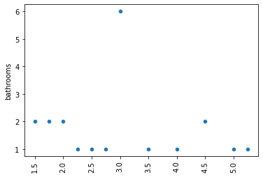

```
Graph for Sqft_living: Total = 18
```

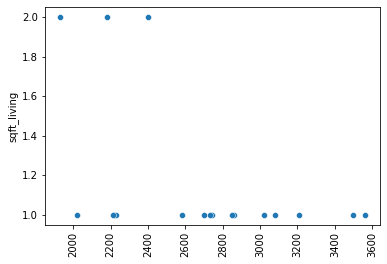

```
Graph for Sqft_lot: Total = 19
```

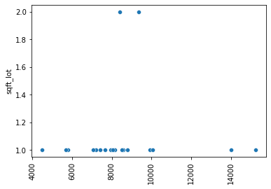

```
Graph for Floors: Total = 3
```

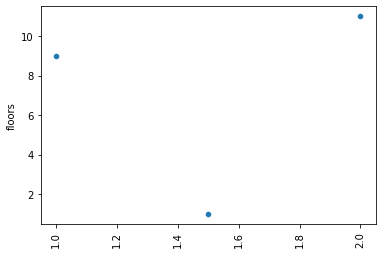

```
Graph for Sqft_above: Total = 18
```

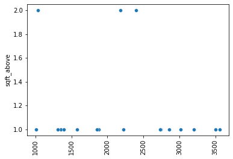

```
Graph for Sqft_basement: Total = 9
```

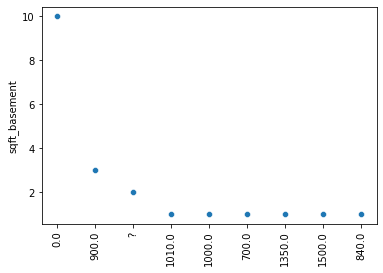

```
Graph for Yr_built: Total = 16
```

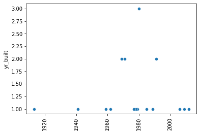

```
Graph for Yr_renovated: Total = 2
```

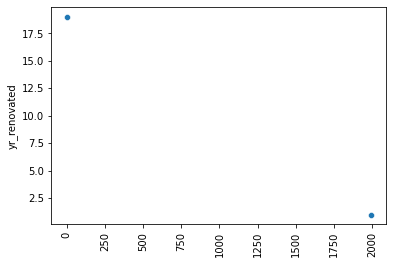

```
Graph for Zipcode: Total = 12
```

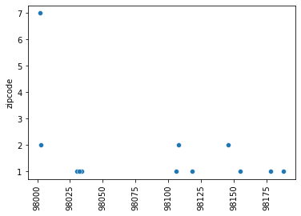

```
Graph for Lat: Total = 19
```

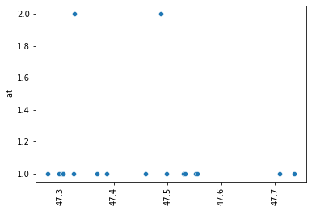

```
Graph for Long: Total = 16
```

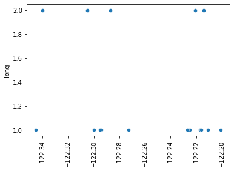

```
Graph for Sqft_living15: Total = 17
```

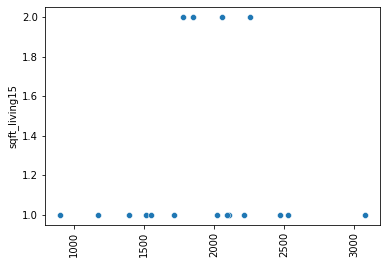

```
Graph for Sqft_lot15: Total = 19
```

[1 more figures not shown]

```python
#plotting scatterplots

def plot_scatterplots():
    for i in cols_to_plot.columns:
        cat_num = cols_to_plot[i].value_counts()
        print('Graph for {}: Total = {}'.format(i.capitalize(), len(cat_num)))
        sns.scatterplot(x=cat_num.index, y=cat_num)
        plt.xticks(rotation=90)
        plt.show()

plot_scatterplots()
```

Conclusion: most of the outliers does not seem to affect our over all need.

```python
#fixing nan values
```

```python
#replacing nan with the mean for yr_renovated
# replace with 0
mean = df_final['yr_renovated'].mean()
df_final['yr_renovated'].replace(np.nan,0,inplace=True)
```

```python
#replacing nan with the mean for waterfront
mean_waterfront = df_final['waterfront'].mode()
df_final['waterfront'].replace(np.nan,mean,inplace=True)
```

```python
# replace waterfront with mode
mean_waterfront
```

```
0    0.0
dtype: float64
```

```python
df_final.info()
```

```
<class 'pandas.core.frame.DataFrame'>
Int64Index: 21 entries, 1476 to 20968
Data columns (total 21 columns):
 #   Column         Non-Null Count  Dtype
---  ------         --------------  -----
 0   id             21 non-null     int64
 1   date           21 non-null     object
 2   price          21 non-null     float64
 3   bedrooms       21 non-null     int64
 4   bathrooms      21 non-null     float64
 5   sqft_living    21 non-null     int64
 6   sqft_lot       21 non-null     int64
 7   floors         21 non-null     float64
 8   waterfront     21 non-null     float64
 9   view           21 non-null     float64
 10  condition      21 non-null     int64
 11  grade          21 non-null     int64
 12  sqft_above     21 non-null     int64
 13  sqft_basement  21 non-null     object
 14  yr_built       21 non-null     int64
 15  yr_renovated   21 non-null     float64
 16  zipcode        21 non-null     int64
 17  lat            21 non-null     float64
 18  long           21 non-null     float64
 19  sqft_living15  21 non-null     int64
 20  sqft_lot15     21 non-null     int64
dtypes: float64(8), int64(11), object(2)
memory usage: 3.6+ KB
```

```python
df_final.describe()
```

|  | id | price | bedrooms | bathrooms | sqft_living | sqft_lot | floors | waterfront | view | condition | grade | sqft_above | yr_built | yr_renovated | zipcode | lat | long | sqft_living15 | sqft_lot15 |
| --- | --- | --- | --- | --- | --- | --- | --- | --- | --- | --- | --- | --- | --- | --- | --- | --- | --- | --- | --- |
| count | 2.100000e+01 | 21.000000 | 21.0 | 21.000000 | 21.000000 | 21.000000 | 21.000000 | 21.000000 | 21.0 | 21.0 | 21.0 | 21.000000 | 21.000000 | 21.000000 | 21.000000 | 21.000000 | 21.000000 | 21.000000 | 21.000000 |
| mean | 4.051965e+09 | 310619.047619 | 6.0 | 2.988095 | 2596.761905 | 8581.761905 | 1.547619 | 9.485714 | 0.0 | 3.0 | 7.0 | 2163.428571 | 1976.761905 | 94.857143 | 98065.190476 | 47.431833 | -122.263714 | 1935.190476 | 10515.857143 |
| std | 3.019198e+09 | 57356.321526 | 0.0 | 1.124934 | 489.105091 | 2441.890720 | 0.497613 | 29.958943 | 0.0 | 0.0 | 0.0 | 813.191525 | 22.205641 | 434.690037 | 69.301240 | 0.137120 | 0.049320 | 485.839646 | 13733.525299 |
| min | 1.000102e+06 | 175000.000000 | 6.0 | 1.500000 | 1930.000000 | 4500.000000 | 1.000000 | 0.000000 | 0.0 | 3.0 | 7.0 | 1010.000000 | 1913.000000 | 0.000000 | 98002.000000 | 47.277300 | -122.345000 | 900.000000 | 5000.000000 |
| 25% | 1.823049e+09 | 280000.000000 | 6.0 | 2.000000 | 2210.000000 | 7416.000000 | 1.000000 | 0.000000 | 0.0 | 3.0 | 7.0 | 1390.000000 | 1969.000000 | 0.000000 | 98002.000000 | 47.305400 | -122.300000 | 1710.000000 | 6000.000000 |
| 50% | 3.021059e+09 | 326000.000000 | 6.0 | 3.000000 | 2580.000000 | 8400.000000 | 2.000000 | 0.000000 | 0.0 | 3.0 | 7.0 | 2180.000000 | 1979.000000 | 0.000000 | 98032.000000 | 47.385900 | -122.273000 | 2020.000000 | 7620.000000 |
| 75% | 7.116501e+09 | 354000.000000 | 6.0 | 3.500000 | 2860.000000 | 9373.000000 | 2.000000 | 0.000000 | 0.0 | 3.0 | 7.0 | 2744.000000 | 1989.000000 | 0.000000 | 98118.000000 | 47.528800 | -122.217000 | 2214.000000 | 8658.000000 |
| max | 9.198600e+09 | 389000.000000 | 6.0 | 5.250000 | 3560.000000 | 15240.000000 | 2.000000 | 99.600000 | 0.0 | 3.0 | 7.0 | 3560.000000 | 2012.000000 | 1992.000000 | 98188.000000 | 47.735100 | -122.201000 | 3078.000000 | 69993.000000 |

```python
# Dataframe_grp.yr_renovated.median()
```

```python
# a.yr_renovated.unique()
```

```python
# a.dropna = b
```

## House Price Distribution

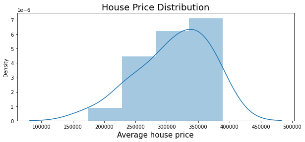

```python
plt.figure(figsize = (10,4))
plt. title('House Price Distribution', size=18)
sns.distplot(df_final["price"])

plt.xlabel('Average house price', size=15)
plt.show()
```

## House prices and number of floors

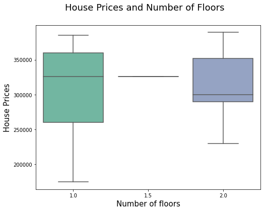

```python
%matplotlib inline
plt.figure(figsize=(8,6))
sns.boxplot(x = df_final['floors'], y= df_final['price'], palette="Set2")
plt.suptitle('House Prices and Number of Floors', size=18)
plt.xlabel('Number of floors', fontsize = 15)
plt.ylabel('House Prices', fontsize =15)

plt.show()
```

```python
# running a comparism
df_final.floors.value_counts()
```

```
2.0    11
1.0     9
1.5     1
Name: floors, dtype: int64
```

```python
pd.pivot_table(df_final, index = 'floors', values= 'yr_built').astype(int)


# House with 3 floors are on the average newer compared to homes with any other number of floors.
```

| floors | yr_built |
| --- | --- |
| 1.0 | 1971 |
| 1.5 | 1913 |
| 2.0 | 1987 |

Conclusion:

[output not shown]

## House Prices with Number of Bathrooms

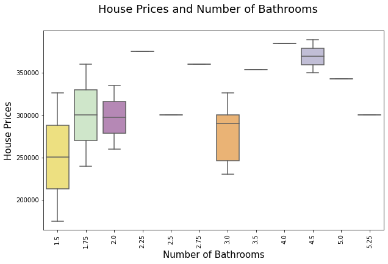

```python
plt.figure(figsize=(10,6))
sns.boxplot(x = df_final['bathrooms'], y= df_final['price'], palette="Set3_r")
plt.suptitle('House Prices and Number of Bathrooms', size=18)
plt.xlabel('Number of Bathrooms', fontsize = 15)
plt.ylabel('House Prices', fontsize = 15)
plt.xticks(rotation=90)

plt.show()



#There seems to be a general uptrend/linear relationship in price with the increase in the number of bathrooms
#Lots of outliers exist in the data
#As the number approaches 5 bathrooms the price begins to fluctuate significantly. This is mainly due to having a limited number of houses that have that many bathrooms within the dataset.
```

Conclusion:

```
•There seems to be a general uptrend/linear relationship in price with the increase in the number of bathrooms.
•As the number approaches 5 bathrooms the price begins to fluctuate significantly. This is mainly due to having a limited number of houses that have that many bathrooms within the dataset.
```

## Neigborhood Price of homes with respect to zipcode

```python
# Create a dataframe for the top 5/bottom 5 zipcodes in terms of average price. Then, combine the dataframes.

pd.options.display.float_format = "{:.2f}".format # Round to 2 decimal places

top = df_final.groupby('zipcode')['price'].mean().reset_index().sort_values('price', ascending=False)[:20]

combined = pd.concat([top])
combined.sort_values('price', ascending=True, inplace=True)
```

```python
combined
```

|  | zipcode | price |
| --- | --- | --- |
| 1 | 98003 | 232500.00 |
| 11 | 98188 | 240000.00 |
| 8 | 98146 | 250500.00 |
| 2 | 98030 | 300000.00 |
| 0 | 98002 | 310285.71 |
| 7 | 98118 | 326000.00 |
| 9 | 98155 | 350000.00 |
| 10 | 98178 | 354000.00 |
| 4 | 98034 | 360000.00 |
| 5 | 98106 | 360000.00 |
| 6 | 98108 | 360000.00 |
| 3 | 98032 | 375000.00 |

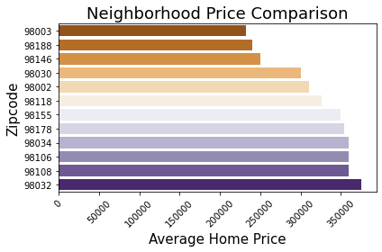

```python
#plt.figure(figsize=(6,8))

sns.barplot(x='price', y='zipcode' , order = combined['zipcode'], orient='h', data=combined, palette="PuOr")

plt.title('Neighborhood Price Comparison', size=18)
plt.ylabel('Zipcode', size=15)
plt.xlabel('Average Home Price', size=15)
plt.xticks(rotation=45)

plt.tight_layout()
plt.savefig('Test2.png')
plt.show()
```

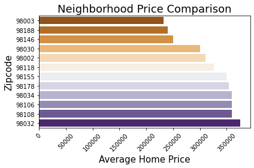

```python
#plt.figure(figsize=(6,8))

sns.barplot(x='price', y='zipcode' , order = combined['zipcode'], orient='h', data=combined, palette="PuOr")

plt.title('Neighborhood Price Comparison', size=18)
plt.ylabel('Zipcode', size=15)
plt.xlabel('Average Home Price', size=15)
plt.xticks(rotation=45)

plt.tight_layout()
plt.savefig('Test2.png')
plt.show()
```

```python
#looking for the zipcode in table
#making zipcode the first columm
df_final_i = df_final.set_index('zipcode')
df_final_i
```

| zipcode | id | date | price | bedrooms | bathrooms | sqft_living | sqft_lot | floors | waterfront | view | condition | grade | sqft_above | sqft_basement | yr_built | yr_renovated | lat | long | sqft_living15 | sqft_lot15 |
| --- | --- | --- | --- | --- | --- | --- | --- | --- | --- | --- | --- | --- | --- | --- | --- | --- | --- | --- | --- | --- |
| 98003 | 2412600030 | 6/23/2014 | 235000.00 | 6 | 3.00 | 2180 | 7956 | 2.00 | 0.00 | 0.00 | 3 | 7 | 2180 | ? | 1980 | 0.00 | 47.31 | -122.31 | 2214 | 7684 |
| 98002 | 1000102 | 9/16/2014 | 280000.00 | 6 | 3.00 | 2400 | 9373 | 2.00 | 99.60 | 0.00 | 3 | 7 | 2400 | 0.0 | 1991 | 0.00 | 47.33 | -122.21 | 2060 | 7316 |
| 98002 | 1000102 | 4/22/2015 | 300000.00 | 6 | 3.00 | 2400 | 9373 | 2.00 | 0.00 | 0.00 | 3 | 7 | 2400 | 0.0 | 1991 | 0.00 | 47.33 | -122.21 | 2060 | 7316 |
| 98146 | 1823049202 | 6/10/2014 | 175000.00 | 6 | 1.50 | 1930 | 8400 | 1.00 | 99.60 | 0.00 | 3 | 7 | 1030 | 900.0 | 1971 | 0.00 | 47.49 | -122.34 | 1780 | 9520 |
| 98146 | 1823049202 | 1/7/2015 | 326000.00 | 6 | 1.50 | 1930 | 8400 | 1.00 | 0.00 | 0.00 | 3 | 7 | 1030 | 900.0 | 1971 | 0.00 | 47.49 | -122.34 | 1780 | 9520 |
| 98108 | 7338402690 | 4/1/2015 | 335000.00 | 6 | 2.00 | 2020 | 7071 | 1.00 | 0.00 | 0.00 | 3 | 7 | 1010 | 1010.0 | 1979 | 0.00 | 47.53 | -122.29 | 2020 | 5000 |
| 98106 | 7972601250 | 2/4/2015 | 360000.00 | 6 | 2.75 | 2850 | 15240 | 1.00 | 0.00 | 0.00 | 3 | 7 | 1850 | 1000.0 | 1962 | 0.00 | 47.53 | -122.34 | 2090 | 7620 |
| 98002 | 5409000110 | 5/6/2015 | 389000.00 | 6 | 4.50 | 3560 | 14010 | 2.00 | 0.00 | 0.00 | 3 | 7 | 3560 | 0.0 | 1989 | 0.00 | 47.32 | -122.22 | 1710 | 11116 |
| 98155 | 1568100300 | 9/17/2014 | 350000.00 | 6 | 4.50 | 3500 | 8504 | 2.00 | 0.00 | 0.00 | 3 | 7 | 3500 | 0.0 | 1980 | 0.00 | 47.74 | -122.30 | 1550 | 8460 |
| 98188 | 9198600035 | 8/5/2014 | 240000.00 | 6 | 1.75 | 2210 | 8594 | 1.00 | 0.00 | 0.00 | 3 | 7 | 1310 | 900.0 | 1959 | 0.00 | 47.46 | -122.27 | 1850 | 8594 |
| 98003 | 2412600070 | 10/30/2014 | 230000.00 | 6 | 3.00 | 2180 | 7220 | 2.00 | 0.00 | 0.00 | 3 | 7 | 2180 | ? | 1980 | 0.00 | 47.30 | -122.31 | 2260 | 7344 |
| 98118 | 6888900060 | 11/16/2014 | 326000.00 | 6 | 3.00 | 2580 | 8064 | 1.50 | 0.00 | 0.00 | 3 | 7 | 1880 | 700.0 | 1913 | 0.00 | 47.55 | -122.29 | 1510 | 6084 |
| 98178 | 1180002470 | 11/4/2014 | 354000.00 | 6 | 3.50 | 3020 | 4500 | 2.00 | 0.00 | 0.00 | 3 | 7 | 3020 | 0.0 | 1941 | 1992.00 | 47.50 | -122.22 | 900 | 6000 |
| 98108 | 7529500030 | 9/9/2014 | 385000.00 | 6 | 4.00 | 2700 | 7416 | 1.00 | 0.00 | 0.00 | 3 | 7 | 1350 | 1350.0 | 1969 | 0.00 | 47.55 | -122.30 | 2260 | 5324 |
| 98030 | 1598600209 | 10/20/2014 | 300000.00 | 6 | 2.50 | 3080 | 8163 | 1.00 | 0.00 | 0.00 | 3 | 7 | 1580 | 1500.0 | 1985 | 0.00 | 47.39 | -122.22 | 1850 | 8658 |
| 98002 | 7116500920 | 5/20/2014 | 300000.00 | 6 | 5.25 | 2860 | 5682 | 2.00 | 0.00 | 0.00 | 3 | 7 | 2860 | 0.0 | 1978 | 0.00 | 47.30 | -122.22 | 1390 | 5956 |
| 98034 | 3558900590 | 11/25/2014 | 360000.00 | 6 | 1.75 | 2230 | 10080 | 1.00 | 0.00 | 0.00 | 3 | 7 | 1390 | 840.0 | 1969 | 0.00 | 47.71 | -122.20 | 2110 | 8475 |
| 98002 | 3141600600 | 5/21/2014 | 260000.00 | 6 | 2.00 | 2220 | 8797 | 1.00 | 0.00 | 0.00 | 3 | 7 | 2220 | 0.0 | 1977 | 0.00 | 47.30 | -122.23 | 1170 | 5123 |
| 98002 | 3021059304 | 9/17/2014 | 300000.00 | 6 | 3.00 | 2744 | 9926 | 2.00 | 0.00 | 0.00 | 3 | 7 | 2744 | 0.0 | 2006 | 0.00 | 47.28 | -122.22 | 2470 | 9926 |
| 98032 | 8946390040 | 5/8/2014 | 375000.00 | 6 | 2.25 | 3206 | 5793 | 2.00 | 0.00 | 0.00 | 3 | 7 | 3206 | 0.0 | 2012 | 0.00 | 47.37 | -122.29 | 2527 | 5804 |
| 98002 | 2149800278 | 10/15/2014 | 343000.00 | 6 | 5.00 | 2732 | 7655 | 2.00 | 0.00 | 0.00 | 3 | 7 | 2732 | 0.0 | 2009 | 0.00 | 47.30 | -122.21 | 3078 | 69993 |

```python
zipcode_rows = [98003,98188,98146,98030,98002,98118,98155,98178,98034,98106,98108,98032]
df_final_i.loc[zipcode_rows]
```

| zipcode | id | date | price | bedrooms | bathrooms | sqft_living | sqft_lot | floors | waterfront | view | condition | grade | sqft_above | sqft_basement | yr_built | yr_renovated | lat | long | sqft_living15 | sqft_lot15 |
| --- | --- | --- | --- | --- | --- | --- | --- | --- | --- | --- | --- | --- | --- | --- | --- | --- | --- | --- | --- | --- |
| 98003 | 2412600030 | 6/23/2014 | 235000.00 | 6 | 3.00 | 2180 | 7956 | 2.00 | 0.00 | 0.00 | 3 | 7 | 2180 | ? | 1980 | 0.00 | 47.31 | -122.31 | 2214 | 7684 |
| 98003 | 2412600070 | 10/30/2014 | 230000.00 | 6 | 3.00 | 2180 | 7220 | 2.00 | 0.00 | 0.00 | 3 | 7 | 2180 | ? | 1980 | 0.00 | 47.30 | -122.31 | 2260 | 7344 |
| 98188 | 9198600035 | 8/5/2014 | 240000.00 | 6 | 1.75 | 2210 | 8594 | 1.00 | 0.00 | 0.00 | 3 | 7 | 1310 | 900.0 | 1959 | 0.00 | 47.46 | -122.27 | 1850 | 8594 |
| 98146 | 1823049202 | 6/10/2014 | 175000.00 | 6 | 1.50 | 1930 | 8400 | 1.00 | 99.60 | 0.00 | 3 | 7 | 1030 | 900.0 | 1971 | 0.00 | 47.49 | -122.34 | 1780 | 9520 |
| 98146 | 1823049202 | 1/7/2015 | 326000.00 | 6 | 1.50 | 1930 | 8400 | 1.00 | 0.00 | 0.00 | 3 | 7 | 1030 | 900.0 | 1971 | 0.00 | 47.49 | -122.34 | 1780 | 9520 |
| 98030 | 1598600209 | 10/20/2014 | 300000.00 | 6 | 2.50 | 3080 | 8163 | 1.00 | 0.00 | 0.00 | 3 | 7 | 1580 | 1500.0 | 1985 | 0.00 | 47.39 | -122.22 | 1850 | 8658 |
| 98002 | 1000102 | 9/16/2014 | 280000.00 | 6 | 3.00 | 2400 | 9373 | 2.00 | 99.60 | 0.00 | 3 | 7 | 2400 | 0.0 | 1991 | 0.00 | 47.33 | -122.21 | 2060 | 7316 |
| 98002 | 1000102 | 4/22/2015 | 300000.00 | 6 | 3.00 | 2400 | 9373 | 2.00 | 0.00 | 0.00 | 3 | 7 | 2400 | 0.0 | 1991 | 0.00 | 47.33 | -122.21 | 2060 | 7316 |
| 98002 | 5409000110 | 5/6/2015 | 389000.00 | 6 | 4.50 | 3560 | 14010 | 2.00 | 0.00 | 0.00 | 3 | 7 | 3560 | 0.0 | 1989 | 0.00 | 47.32 | -122.22 | 1710 | 11116 |
| 98002 | 7116500920 | 5/20/2014 | 300000.00 | 6 | 5.25 | 2860 | 5682 | 2.00 | 0.00 | 0.00 | 3 | 7 | 2860 | 0.0 | 1978 | 0.00 | 47.30 | -122.22 | 1390 | 5956 |
| 98002 | 3141600600 | 5/21/2014 | 260000.00 | 6 | 2.00 | 2220 | 8797 | 1.00 | 0.00 | 0.00 | 3 | 7 | 2220 | 0.0 | 1977 | 0.00 | 47.30 | -122.23 | 1170 | 5123 |
| 98002 | 3021059304 | 9/17/2014 | 300000.00 | 6 | 3.00 | 2744 | 9926 | 2.00 | 0.00 | 0.00 | 3 | 7 | 2744 | 0.0 | 2006 | 0.00 | 47.28 | -122.22 | 2470 | 9926 |
| 98002 | 2149800278 | 10/15/2014 | 343000.00 | 6 | 5.00 | 2732 | 7655 | 2.00 | 0.00 | 0.00 | 3 | 7 | 2732 | 0.0 | 2009 | 0.00 | 47.30 | -122.21 | 3078 | 69993 |
| 98118 | 6888900060 | 11/16/2014 | 326000.00 | 6 | 3.00 | 2580 | 8064 | 1.50 | 0.00 | 0.00 | 3 | 7 | 1880 | 700.0 | 1913 | 0.00 | 47.55 | -122.29 | 1510 | 6084 |
| 98155 | 1568100300 | 9/17/2014 | 350000.00 | 6 | 4.50 | 3500 | 8504 | 2.00 | 0.00 | 0.00 | 3 | 7 | 3500 | 0.0 | 1980 | 0.00 | 47.74 | -122.30 | 1550 | 8460 |
| 98178 | 1180002470 | 11/4/2014 | 354000.00 | 6 | 3.50 | 3020 | 4500 | 2.00 | 0.00 | 0.00 | 3 | 7 | 3020 | 0.0 | 1941 | 1992.00 | 47.50 | -122.22 | 900 | 6000 |
| 98034 | 3558900590 | 11/25/2014 | 360000.00 | 6 | 1.75 | 2230 | 10080 | 1.00 | 0.00 | 0.00 | 3 | 7 | 1390 | 840.0 | 1969 | 0.00 | 47.71 | -122.20 | 2110 | 8475 |
| 98106 | 7972601250 | 2/4/2015 | 360000.00 | 6 | 2.75 | 2850 | 15240 | 1.00 | 0.00 | 0.00 | 3 | 7 | 1850 | 1000.0 | 1962 | 0.00 | 47.53 | -122.34 | 2090 | 7620 |
| 98108 | 7338402690 | 4/1/2015 | 335000.00 | 6 | 2.00 | 2020 | 7071 | 1.00 | 0.00 | 0.00 | 3 | 7 | 1010 | 1010.0 | 1979 | 0.00 | 47.53 | -122.29 | 2020 | 5000 |
| 98108 | 7529500030 | 9/9/2014 | 385000.00 | 6 | 4.00 | 2700 | 7416 | 1.00 | 0.00 | 0.00 | 3 | 7 | 1350 | 1350.0 | 1969 | 0.00 | 47.55 | -122.30 | 2260 | 5324 |
| 98032 | 8946390040 | 5/8/2014 | 375000.00 | 6 | 2.25 | 3206 | 5793 | 2.00 | 0.00 | 0.00 | 3 | 7 | 3206 | 0.0 | 2012 | 0.00 | 47.37 | -122.29 | 2527 | 5804 |

```python
df_final.head(2)
```

|  | id | date | price | bedrooms | bathrooms | sqft_living | sqft_lot | floors | waterfront | view | ... | grade | sqft_above | sqft_basement | yr_built | yr_renovated | zipcode | lat | long | sqft_living15 | sqft_lot15 |
| --- | --- | --- | --- | --- | --- | --- | --- | --- | --- | --- | --- | --- | --- | --- | --- | --- | --- | --- | --- | --- | --- |
| 1476 | 2412600030 | 6/23/2014 | 235000.00 | 6 | 3.00 | 2180 | 7956 | 2.00 | 0.00 | 0.00 | ... | 7 | 2180 | ? | 1980 | 0.00 | 98003 | 47.31 | -122.31 | 2214 | 7684 |
| 2494 | 1000102 | 9/16/2014 | 280000.00 | 6 | 3.00 | 2400 | 9373 | 2.00 | 99.60 | 0.00 | ... | 7 | 2400 | 0.0 | 1991 | 0.00 | 98002 | 47.33 | -122.21 | 2060 | 7316 |

2 rows × 21 columns

```python
# group by zip code
#Data
#frame_zipcode = dataframe_grp.query(" zipcode" )
#Dataframe_grp

df_final_zipcode = df_final.groupby("zipcode").mean().sort_values("price").reset_index()
df_final_zipcode.head(2)
```

|  | zipcode | id | price | bedrooms | bathrooms | sqft_living | sqft_lot | floors | waterfront | view | condition | grade | sqft_above | yr_built | yr_renovated | lat | long | sqft_living15 | sqft_lot15 |
| --- | --- | --- | --- | --- | --- | --- | --- | --- | --- | --- | --- | --- | --- | --- | --- | --- | --- | --- | --- |
| 0 | 98003 | 2412600050.00 | 232500.00 | 6.00 | 3.00 | 2180.00 | 7588.00 | 2.00 | 0.00 | 0.00 | 3.00 | 7.00 | 2180.00 | 1980.00 | 0.00 | 47.30 | -122.31 | 2237.00 | 7514.00 |
| 1 | 98188 | 9198600035.00 | 240000.00 | 6.00 | 1.75 | 2210.00 | 8594.00 | 1.00 | 0.00 | 0.00 | 3.00 | 7.00 | 1310.00 | 1959.00 | 0.00 | 47.46 | -122.27 | 1850.00 | 8594.00 |

```python
# Load zipcode areas county from .geojson file.
with open('data/Zip_Codes.geojson') as f:
    gj = geojson.load(f)

#
for i in range(len(gj['features'])):
    gj['features'][i]['id'] = gj['features'][i]['properties']['ZIPCODE']
```

```python
#Dataframe_zipcode1
# Build a geoplot to show the cheap and expensive area in King county
fig1 = px.choropleth_mapbox(df_final_zipcode,geojson=gj, locations="zipcode",color="price",
                           color_continuous_scale="PiYG",
                           #range_color=(100,600),
                           mapbox_style="open-street-map",
                           zoom=8, center={"lat": 47.373348, "lon": -122.036926},
                           opacity=0.7)


fig1.update_layout(margin={"r":0,"t":0,"l":0,"b":0})
fig1.update_geos(fitbounds="locations", visible=False,center={"lat": 47.47, "lon": 47.47 -121.84})
fig1.show()
```

[output not shown]

## General Zipcode Price comparison

```python
# Let's visualize the price distirubtion for all zipcodes on a map.

zipcode_prices = df.groupby('zipcode')['price'].mean().reset_index().sort_values('price', ascending=False)
zipcode_prices['zipcode'] = zipcode_prices['zipcode'].astype(str)
zipcode_prices
```

|  | zipcode | price |
| --- | --- | --- |
| 24 | 98039 | 2161300.00 |
| 3 | 98004 | 1356523.99 |
| 25 | 98040 | 1194873.64 |
| 48 | 98112 | 1096239.01 |
| 41 | 98102 | 899607.67 |
| ... | ... | ... |
| 61 | 98148 | 284908.60 |
| 0 | 98001 | 281194.87 |
| 20 | 98032 | 251296.24 |
| 64 | 98168 | 240328.37 |
| 1 | 98002 | 234284.04 |

70 rows × 2 columns

```python
#Dataframe_zipcode1
# Build a geoplot to show the cheap and expensive area in King county
fig1 = px.choropleth_mapbox(zipcode_prices,geojson=gj, locations="zipcode",color="price",
                           color_continuous_scale="PiYG",
                           #range_color=(100,600),
                           mapbox_style="open-street-map",
                           zoom=8, center={"lat": 47.373348, "lon": -122.036926},
                           opacity=0.7)


fig1.update_layout(margin={"r":0,"t":0,"l":0,"b":0})
fig1.update_geos(fitbounds="locations", visible=False,center={"lat": 47.47, "lon": 47.47 -121.84})
fig1.show()
```

[output not shown]

## House Price and Size Comprison

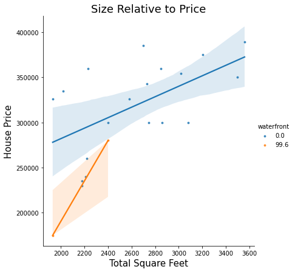

```python
sns.lmplot(x='sqft_living', y='price', data= df_final, scatter_kws={'s':8}, hue='waterfront', height=6)

plt.title('Size Relative to Price', size=18)
plt.ylabel('House Price', size=15)
plt.xlabel('Total Square Feet', size=15)


plt.show()
```

Lets Compare it with the the general data set

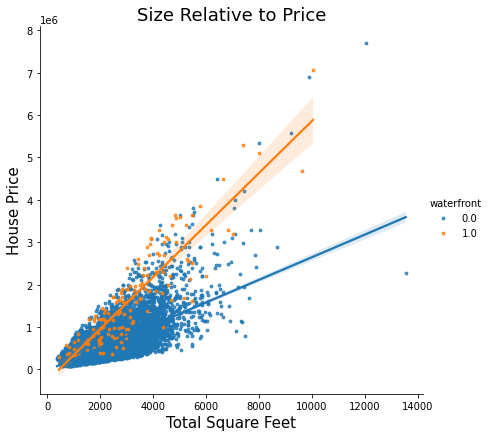

```python
sns.lmplot(x='sqft_living', y='price', data= df, scatter_kws={'s':8}, hue='waterfront', height=6)

plt.title('Size Relative to Price', size=18)
plt.ylabel('House Price', size=15)
plt.xlabel('Total Square Feet', size=15)


plt.show()
```

The baseline price for waterfront properties is higher on average than those without a waterfront As the house size increases, the price gap significantly widens between waterfront/non waterfront

## Year Built and Price

```python
# there are i6 different years within the df_final dataset

df_final.yr_built.nunique()
```

```
16
```

```python
# making sure there are no null values

df_final.yr_built.isnull().sum()
```

```
0
```

```python
print(df_final.yr_built.min())
print(df_final.yr_built.max())
```

```
1913
2012
```

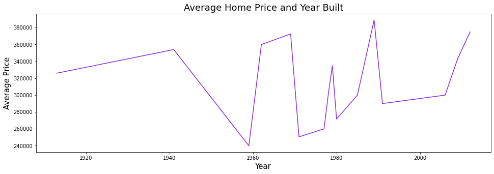

```python
plt.figure(figsize=(16,5))

sns.lineplot(x='yr_built', y='price', data=df_final,linewidth=1.5, color='blueviolet', ci=None)

plt.title('Average Home Price and Year Built', size=18)
plt.ylabel('Average Price', size=15)
plt.xlabel('Year', size=15)

plt.show()
```

Lets Compare with the general data set

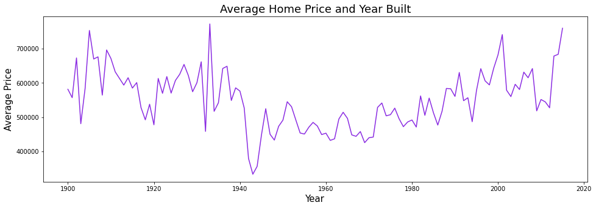

```python
plt.figure(figsize=(16,5))

sns.lineplot(x='yr_built', y='price', data=df,linewidth=1.5, color='blueviolet', ci=None)

plt.title('Average Home Price and Year Built', size=18)
plt.ylabel('Average Price', size=15)
plt.xlabel('Year', size=15)

plt.show()
```

•House built before 1940 and between aproximately 1990 and 2000 have a higher average price. •Houses approximately between 1945 to 1980 cost less on average • could this be due to the fact that the very old houses (before 1940) may have been renovated?

# Correlation between Variables

```python
# Lets remove the columns which do not need from our df_final dataframe


df_final.drop(['id', 'bedrooms','waterfront','view','condition','grade'],axis = 1, inplace = True)
```

```python
df_final.columns.tolist()
```

```
['date',
 'price',
 'bathrooms',
 'sqft_living',
 'sqft_lot',
 'floors',
 'sqft_above',
 'sqft_basement',
 'yr_built',
 'yr_renovated',
 'zipcode',
 'lat',
 'long',
 'sqft_living15',
 'sqft_lot15']
```

```python
cols = ['date',
 'price',
 'bathrooms',
 'sqft_living',
 'sqft_lot',
 'floors',
 'sqft_above',
 'sqft_basement',
 'yr_built',
 'yr_renovated',
 'zipcode',
 'lat',
 'long',
 'sqft_living15',
 'sqft_lot15']
```

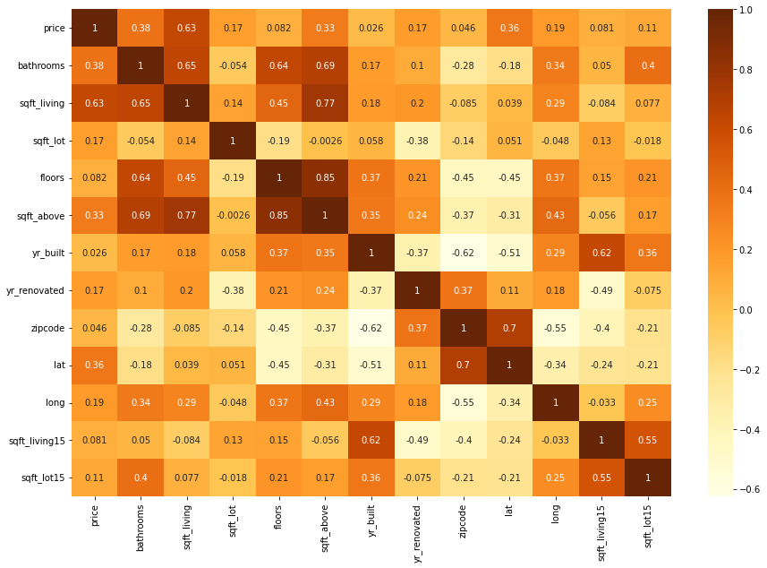

```python
corr = df_final.corr()

plt.figure(figsize=(15,10))
sns.heatmap(corr, cmap='YlOrBr', annot=True)

plt.show()
```

- sqft_living has a strong correlation with price

```python
high_corr = df_final.corr()['price'].sort_values(ascending=False)
high_corr
```

```
price           1.00
sqft_living     0.63
bathrooms       0.38
lat             0.36
sqft_above      0.33
long            0.19
yr_renovated    0.17
sqft_lot        0.17
sqft_lot15      0.11
floors          0.08
sqft_living15   0.08
zipcode         0.05
yr_built        0.03
Name: price, dtype: float64
```

Lets compare with the general data set

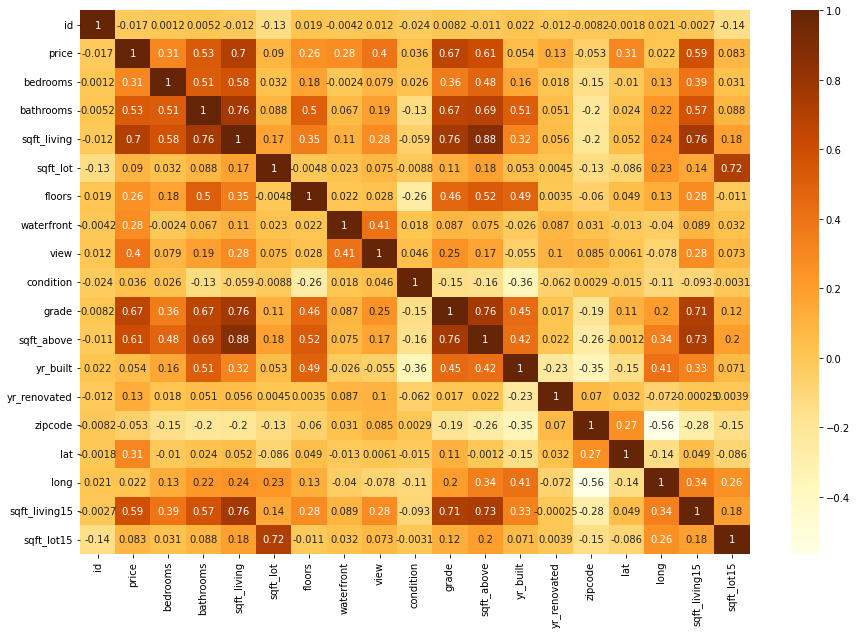

```python
corr = df.corr()

plt.figure(figsize=(15,10))
sns.heatmap(corr, cmap='YlOrBr', annot=True)

plt.show()
```

# Summary

We can recommend the following Neighborhood for our stakeholder Mr Thomas:

- zipcode 98106
- zipcode 98108
- zipcode 98118
- zipcode 98146
- zipcode 98188

All this neigborhoods are with Mr. Thomas budgets and the require little or no maintaince.

Thank you for going through these notebook, your comments are highly welcommed.